# Are the Michelin Star Rankings Biased?

### Introduction:

https://guide.michelin.com/th/en/to-the-stars-and-beyond-th

The Michelin Star rating system has existed for decades as a means of rating restaurants around the world. It is generally considered one of the most significant restaurant ranking systems in the world, but it is not without its flaws. Many articles have been written about the perceived bias of the rating system, in particular how it seems to favor French and Japanese cuisine and is very unobjective in its analysis. Michelin rankings are incredibly important to chefs and the pressure surrounding them has even contributed to chefs committing suicide.

https://www.scmp.com/lifestyle/food-drink/article/2183133/criticism-controversies-suicides-brief-history-michelin-guide

https://frenchly.us/is-the-michelin-guide-prejudiced/

Thus I believe it is an incredibly important subject to analyze. Michelin Stars have significant impacts of business, tourism, and the economics of areas with more of them and if they are not distributed in an equitable and unprejudiced way, it could have significant negative impacts on marginalized communites and countries.

### My Hypotheses:

Based on my research, I have several hypothesis regarding the Michelin Star rating system. First, I believe that I will discover that Michelin does tend to give more stars to restaurants serving French and Japanese cuisine, as well as restaurants that are more expensive. I believe that restaurants in Western countries will be given more stars, both overall and per capita, compared to non-Western countries. I believe that areas with higher per capita car ownership will have more Michelin stars (I will talk more about why later). And finally, I believe a restaurant's star rating will likely be able to be reliably predicted by a machine learning algorithm because of these biases.

### Wrangling Data!:

First I need to import the csv files I found on Kaggle. As the price columns are encoded as strings of dollar signs, I can convert them into numeric values, representing the average price of the food at a particular restaurant.

Dataset Source: https://www.kaggle.com/jackywang529/michelin-restaurants

```python
import folium
import requests
import pandas


one_star = pandas.read_csv("one-star-michelin-restaurants.csv")
two_star = pandas.read_csv("two-stars-michelin-restaurants.csv")
three_star = pandas.read_csv("three-stars-michelin-restaurants.csv")

pandas.set_option('display.max_rows', None)


for index, row in one_star.iterrows():
    if one_star.at[index, "price"] == "$$$$$":
        one_star.at[index, "price"] = 5
    elif one_star.at[index, "price"] == "$$$$":
        one_star.at[index, "price"] = 4
    elif one_star.at[index, "price"] == "$$$":
        one_star.at[index, "price"] = 3
    elif one_star.at[index, "price"] == "$$":
        one_star.at[index, "price"] = 2
    elif one_star.at[index, "price"] == "$":
        one_star.at[index, "price"] = 1

for index, row in two_star.iterrows():
    if two_star.at[index, "price"] == "$$$$$":
        two_star.at[index, "price"] = 5
    elif two_star.at[index, "price"] == "$$$$":
        two_star.at[index, "price"] = 4
    elif two_star.at[index, "price"] == "$$$":
        two_star.at[index, "price"] = 3
    elif two_star.at[index, "price"] == "$$":
        two_star.at[index, "price"] = 2
    elif two_star.at[index, "price"] == "$":
        two_star.at[index, "price"] = 1

for index, row in three_star.iterrows():
    if three_star.at[index, "price"] == "$$$$$":
        three_star.at[index, "price"] = 5
    elif three_star.at[index, "price"] == "$$$$":
        three_star.at[index, "price"] = 4
    elif three_star.at[index, "price"] == "$$$":
        three_star.at[index, "price"] = 3
    elif three_star.at[index, "price"] == "$$":
        three_star.at[index, "price"] = 2
    elif three_star.at[index, "price"] == "$":
        three_star.at[index, "price"] = 1

two_star.head()
```

|  | name | year | latitude | longitude | city | region | zipCode | cuisine | price | url |
| --- | --- | --- | --- | --- | --- | --- | --- | --- | --- | --- |
| 0 | SENNS.Restaurant | 2019 | 47.83636 | 13.06389 | Salzburg | Austria | 5020 | Creative | 5 | https://guide.michelin.com/at/en/salzburg-regi... |
| 1 | Ikarus | 2019 | 47.79536 | 13.00695 | Salzburg | Austria | 5020 | Creative | 5 | https://guide.michelin.com/at/en/salzburg-regi... |
| 2 | Mraz & Sohn | 2019 | 48.23129 | 16.37637 | Wien | Austria | 1200 | Creative | 5 | https://guide.michelin.com/at/en/vienna/wien/r... |
| 3 | Konstantin Filippou | 2019 | 48.21056 | 16.37996 | Wien | Austria | 1010 | Modern cuisine | 5 | https://guide.michelin.com/at/en/vienna/wien/r... |
| 4 | Silvio Nickol Gourmet Restaurant | 2019 | 48.20558 | 16.37693 | Wien | Austria | 1010 | Modern cuisine | 5 | https://guide.michelin.com/at/en/vienna/wien/r... |

There are also some prices that we do not know (NaN) so I need to replace them with useful values. First I found the mean price for the restaurants in each respective dataframe.

```python
one_star["price"].mean()
```

```
3.2437185929648242
```

```python
two_star["price"].mean()
```

```
3.888888888888889
```

```python
three_star["price"].mean()
```

```
3.935483870967742
```

For one star restaurants it is close to 3 and for two and three star restaurants it is closer to 4, so those are the values we will use to replace the NaN values.

```python
one_star['price'] = one_star['price'].fillna(3)
two_star['price'] = two_star['price'].fillna(4)
three_star['price'] = three_star['price'].fillna(4)
```

We can drop some columns as well. URL, year, and zipCode aren't really that useful for our needs so we can drop those.

```python
one_star.drop(columns=['zipCode', 'year', 'url'], inplace=True)
two_star.drop(columns=['zipCode', 'year', 'url'], inplace=True)
three_star.drop(columns=['zipCode', 'year', 'url'], inplace=True)
```

While having the three dataframes, one for each number of stars, seperately is helpful, it is also useful to have the three dataframes combined into one. So we can make a new one called all_stars that contains all the columns from all three. However, we need some way to differentiate the number of stars once they are combined so we need a new column, num_stars, for each dataframe. Then we can concat them all together. Also, I used ignore_index=True to reset the indices of the rows (otherwise, we could have 3 of the same index for many indices)

```python
one_star['num_stars'] = 1
two_star['num_stars'] = 2
three_star['num_stars'] = 3
all_stars = pandas.concat([one_star, two_star, three_star], ignore_index=True)
#all_stars.drop(columns=['zipCode', 'year', 'url'], inplace=True)
all_stars.head(10)
```

|  | name | latitude | longitude | city | region | cuisine | price | num_stars |
| --- | --- | --- | --- | --- | --- | --- | --- | --- |
| 0 | Kilian Stuba | 47.348580 | 10.17114 | Kleinwalsertal | Austria | Creative | 5 | 1 |
| 1 | Pfefferschiff | 47.837870 | 13.07917 | Hallwang | Austria | Classic cuisine | 5 | 1 |
| 2 | Esszimmer | 47.806850 | 13.03409 | Salzburg | Austria | Creative | 5 | 1 |
| 3 | Carpe Diem | 47.800010 | 13.04006 | Salzburg | Austria | Market cuisine | 5 | 1 |
| 4 | Edvard | 48.216503 | 16.36852 | Wien | Austria | Modern cuisine | 4 | 1 |
| 5 | Das Loft | 48.212720 | 16.37931 | Wien | Austria | Modern cuisine | 5 | 1 |
| 6 | Pramerl & the Wolf | 48.209450 | 16.37174 | Wien | Austria | Creative | 5 | 1 |
| 7 | Walter Bauer | 48.209230 | 16.37672 | Wien | Austria | Classic cuisine | 5 | 1 |
| 8 | SHIKI | 48.204067 | 16.37098 | Wien | Austria | Japanese | 5 | 1 |
| 9 | Tian | 48.205130 | 16.37456 | Wien | Austria | Vegetarian | 5 | 1 |

We are also going to need a Continent column. This one is a big more difficult but can be created using Python sets.

```python
#all_stars.head(1000)

#sets of all the regions in the dataset
europe = {'Austria', 'Croatia', 'Czech Republic', 'Denmark', 'Finland', 'Greece', 'Hungary', 'Norway', 'Poland', 'Ireland', 'United Kingdom', 'Sweden', 'Austria'}
north_am = {'California', 'Chicago', 'New York City', 'Washington DC'}
asia = {'Hong Kong', 'Macau', 'South Korea'}
south_am = {'Rio de Janeiro', 'Sao Paulo', 'Singapore', 'Taipei', 'Thailand'}
oceania = {}


all_stars['continent'] = ""
for index, row in all_stars.iterrows():
    if all_stars.at[index, "region"] in europe:
        all_stars.at[index, 'continent'] = "Europe"
    elif all_stars.at[index, "region"] in north_am:
        all_stars.at[index, 'continent'] = "North America"
    elif all_stars.at[index, "region"] in south_am:
        all_stars.at[index, 'continent'] = "South America"
    elif all_stars.at[index, "region"] in asia:
        all_stars.at[index, 'continent'] = "Asia"
    else:
        all_stars.at[index, 'continent'] = "Africa"
all_stars.head()
```

|  | name | latitude | longitude | city | region | cuisine | price | num_stars | continent |
| --- | --- | --- | --- | --- | --- | --- | --- | --- | --- |
| 0 | Kilian Stuba | 47.348580 | 10.17114 | Kleinwalsertal | Austria | Creative | 5 | 1 | Europe |
| 1 | Pfefferschiff | 47.837870 | 13.07917 | Hallwang | Austria | Classic cuisine | 5 | 1 | Europe |
| 2 | Esszimmer | 47.806850 | 13.03409 | Salzburg | Austria | Creative | 5 | 1 | Europe |
| 3 | Carpe Diem | 47.800010 | 13.04006 | Salzburg | Austria | Market cuisine | 5 | 1 | Europe |
| 4 | Edvard | 48.216503 | 16.36852 | Wien | Austria | Modern cuisine | 4 | 1 | Europe |

Ok, now we are done wrangling and can start!

### Analysis:

First, I am going to produce a stacked bar plot, showing the amount of restaurants with different amounts of Michelin stars on each continent (not including Antarctica of course).

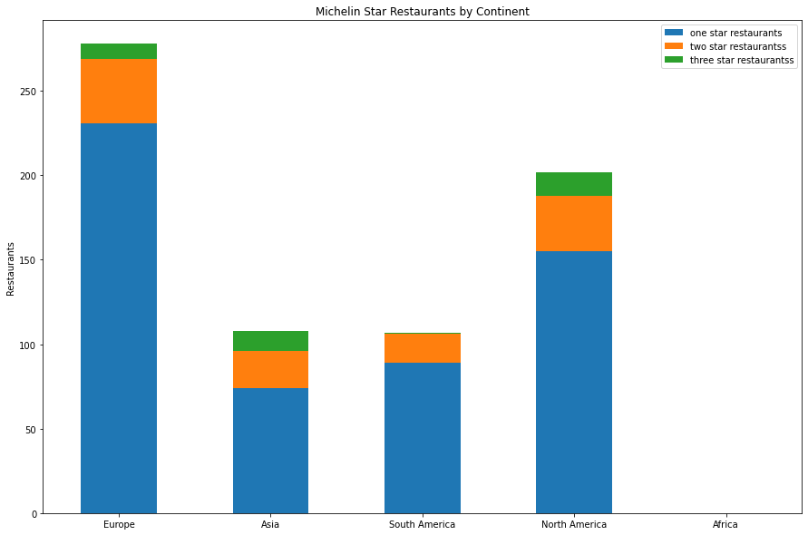

```python
af_one = 0
af_two = 0
af_three = 0
e_one = 0
e_two = 0
e_three = 0
n_one = 0
n_two = 0
n_three = 0
s_one = 0
s_two = 0
s_three = 0
a_one = 0
a_two = 0
a_three = 0

for index, row in all_stars.iterrows():
    if all_stars.at[index, 'continent'] == "Europe":
        if all_stars.at[index, 'num_stars'] == 1:
            e_one += 1
        elif all_stars.at[index, 'num_stars'] == 2:
            e_two += 1
        else:
            e_three += 1
    elif all_stars.at[index, 'continent'] == "Asia":
        if all_stars.at[index, 'num_stars'] == 1:
            a_one += 1
        elif all_stars.at[index, 'num_stars'] == 2:
            a_two += 1
        elif all_stars.at[index, 'num_stars'] == 3:
            a_three += 1
    elif all_stars.at[index, 'continent'] == "South America":
        if all_stars.at[index, 'num_stars'] == 1:
            s_one += 1
        elif all_stars.at[index, 'num_stars'] == 2:
            s_two += 1
        elif all_stars.at[index, 'num_stars'] == 3:
            s_three += 1
    elif all_stars.at[index, 'continent'] == "North America":
        if all_stars.at[index, 'num_stars'] == 1:
            n_one += 1
        elif all_stars.at[index, 'num_stars'] == 2:
            n_two += 1
        elif all_stars.at[index, 'num_stars'] == 3:
            n_three += 1
    else:
        if all_stars.at[index, 'num_stars'] == 1:
            af_one += 1
        elif all_stars.at[index, 'num_stars'] == 2:
            af_two += 1
        elif all_stars.at[index, 'num_stars'] == 3:
            af_three += 1

#create arrays of the star counts for each continent and form them into stacked bar plots
one_counts = [e_one, a_one, s_one, n_one, af_one]
two_counts = [e_two, a_two, s_two, n_two, af_two]
three_counts = [e_three, a_three, s_three, n_three, af_three]
index = ["Europe", "Asia", "South America", "North America", "Africa"]
df = pandas.DataFrame({'one star restaurants': one_counts,'two star restaurantss': two_counts, 'three star restaurantss': three_counts}, index=index)
ax = df.plot.bar(stacked=True, rot=0, figsize=(15, 10), title="Michelin Star Restaurants by Continent")
ax.set_ylabel("Restaurants")
```

As we can see, Europe has significantly more one and two star restaurants than every other country. The United States actually has slightly more three star restaurants than Europe but fewer one and two star restaurants. Asia and South America have nearly the same amount of starred restaurants, but more of South America's are only one star and almost none are three starred. And Africa unfortuantely does not have any Michelin stars. This data alone suggests that the Michelin star rating system is in fact very biased and unobjective. As Michelin is a French company, it makes sense that more of their starred restaurants are in Europe. However, it seems very unfair and prejudiced of Michelin to have not given even one star to any of the thousands of restaurants in Africa. Several articles have been written about this phenomenan, with several restaurants hoping to become the first starred restaurant in Africa.

https://www.theeastafrican.co.ke/tea/magazine/three-michelin-star-chef-mutaro-balde-s-visit-excites-chefs-in-kigali-1420718#:~:text=There%20are%20no%20Michelin%20starred,entrepreneur%20Hassan%20Odukale%20in%20London.

https://www.euronews.com/culture/2022/01/04/meet-the-man-hoping-to-create-africa-s-first-michelin-starred-restaurant

What is interesting is that there are African chefs with restaurants serving African food that have been awarded stars on other continents, like Europe, but none in Africa. Michelin should make more effort to promoting diversity and equity in their awarding of stars. It is also worth noting that there are no Michelin star restaurants in Oceania, the continent of Australia and New Zealand. So from the above bar graph, we can see that Michelin is likely biased in favor of European and North American restaurants.

We can also look at the total number of stars awarded to each continent with some simple code changes. The results are quite similar but a bit readable.

```python
one_counts = [e_one, a_one, s_one, n_one, af_one]
two_counts = [e_two, a_two, s_two, n_two, af_two]
three_counts = [e_three, a_three, s_three, n_three, af_three]
e_total = (e_one + (2*e_two) + (3*e_three))
a_total = (a_one + (2*a_two) + (3*a_three))
s_total = (s_one + (2*s_two) + (3*s_three))
n_total = (n_one + (2*n_two) + (3*n_three))
af_total = (af_one + (2*af_two) + (3*af_three))

total = [e_total, a_total, s_total, n_total, af_total]
index = ["Europe", "Asia", "South America", "North America", "Africa"]
df = pandas.DataFrame({'total star count': total}, index=index)
ax = df.plot.bar(rot=0, figsize=(15, 10), title="Total Michelin Stars Awarded by Continent")
```

[output not shown]

As I said previously, I felt that there could be a positive relationship between car ownership and Michelin Stars awarded. The reason for this is that Michelin is actually a car tire company and that the reason the Michelin Star system was created was actually to encourage people to drive more by visiting restaurants and other attractions far away.

https://bettermarketing.pub/how-this-tire-company-created-the-worlds-most-famous-food-guide-370376bcf01a

Because of this, I think car ownership rates by continent would be a worthwhile datapoint to examine.

https://hedgescompany.com/blog/2021/06/how-many-cars-are-there-in-the-world/

The above website lists cars per capita by continent: 1): North America: 0.71 vehicles per capita/710 vehicles per thousand people 2). Europe: 0.52 vehicles per capita/520 vehicles per thousand people 3). South America: 0.22 vehicles per capita/220 vehicles per thousand people 4). Middle East: 0.18 vehicles per capita/180 vehicles per thousand people 5). Asia/Pacific: 0.14 vehicles per capita/140 vehicles per thousand people 6). Africa: 0.05 vehicles per capita/50 vehicles per thousand people 7). Antarctica: 0.05 vehicles per capita/50 vehicles per thousand people

While the Middle East is compromised of countries in Europe, Asia, and Africa, most of the countries are in Asia so for convenience I will include that value with Asia.

```python
n_cars = 0.71
e_cars = 0.52
s_cars = 0.22
a_cars = 0.18 + 0.14
af_cars = 0.05

total = [e_cars, a_cars, s_cars, n_cars, af_cars]
index = ["Europe", "Asia", "South America", "North America", "Africa"]
df = pandas.DataFrame({'Cars Per 1000 People': total}, index=index)
ax = df.plot.bar(rot=0, figsize=(15, 10), title="Cars Owned Per 1000 People by Continent")
```

[output not shown]

And unsuprisingly, we see a very similar relationship to the previous plot. North America and Europe are the highest (although Europe and North America's relative sizes are swapped compared to the previous graph), Asia and South America are lower, and Africa is the lowest. While Michelin is definitely biased in terms of contients, it is possible that bias could be due to profit incentives. In areas with fewer cars, they cannot sell as many tires. That said they should still obviously make a greater effort to represent marginalized countries in their starred restaurants.

Next I will examine the relationship between total stars awarded and cuisine type. This can be done in linear time uses a Python dictionary and a for loop. Unfortunately there are too many to plot in a readable way, as well as sub-classifcations (French and Classic French are different cateogries, for example) so I will just print them.

```python
cuisine_stars = {}

for index, row in all_stars.iterrows():

    if all_stars.at[index, 'cuisine'] not in cuisine_stars:
        cuisine_stars[all_stars.at[index, 'cuisine']] = all_stars.at[index, 'num_stars']
    else:
        cuisine_stars[all_stars.at[index, 'cuisine']] += all_stars.at[index, 'num_stars']

for key, value in cuisine_stars.items():
     print(key, '->', value, 'stars')
```

```
Creative -> 66 stars
Classic cuisine -> 16 stars
Market cuisine -> 1 stars
Modern cuisine -> 121 stars
Japanese -> 66 stars
Vegetarian -> 2 stars
Contemporary -> 113 stars
Indian -> 13 stars
Korean -> 19 stars
Californian -> 15 stars
American -> 12 stars
International -> 1 stars
Moroccan -> 1 stars
Thai -> 13 stars
Chinese -> 19 stars
Fusion -> 4 stars
Italian -> 24 stars
French -> 42 stars
Asian -> 4 stars
Steakhouse -> 6 stars
Mexican -> 7 stars
Gastropub -> 2 stars
Danish -> 1 stars
Classic French -> 5 stars
Finnish -> 1 stars
Mediterranean -> 4 stars
Seafood -> 17 stars
Cantonese -> 53 stars
Dim Sum -> 1 stars
Teppanyaki -> 1 stars
Sushi -> 23 stars
Shanghainese -> 3 stars
Noodles and congee -> 1 stars
Innovative -> 36 stars
Cantonese Roast Meats -> 2 stars
Taizhou -> 1 stars
Sichuan -> 1 stars
European contemporary -> 8 stars
Scandinavian -> 7 stars
Austrian -> 1 stars
```

[output cut: 15 more lines]

```
Taiwanese -> 3 stars
Hang Zhou -> 1 stars
Asian contemporary -> 1 stars
Thai Contemporary -> 2 stars
Southern Thai -> 1 stars
European -> 1 stars
Creative British -> 3 stars
Traditional British -> 7 stars
Regional cuisine -> 1 stars
Mediterranean cuisine -> 1 stars
Creative French -> 4 stars
Modern French -> 5 stars
Hunanese and Sichuan -> 2 stars
Japanese contemporary -> 4 stars
Sichuan-Huai Yang -> 2 stars
```

My inital hypothesis based on my research was that French and Japanese cuisine would be awarded the most stars. However, this does not appear to be the case. The total counts across all French and Japanese styles are the following:

Japanese = 66, Teppanyaki = 1, Sushi = 23

Total = 90

French = 42, Classic French = 5, French contemporary = 30, Creative French = 4, Modern French = 5,

Total = 86

Modern and Contemporary style cuisine both have more stars, with 121 and 113 stars, respectively. French and Japanese cooking are certainly AMONG the most popular to Michelin, but they seem to favor new and innovative cooking even more than French and Japanese. However, this still certainly displays a noticable level of bias among the styles of cuisine awarded by Michelin. For example, despite making up a large portion of the world, I can only see one African or Middle eastern cuisine restaurant with a star. This is indicative of strong bias in Michelin's favored restaurants.

Next I will examine the relationship between number of stars awarded and the price of restaurants. My hypothesis was that Michelin would favor more expensive restaurants and award them more stars.

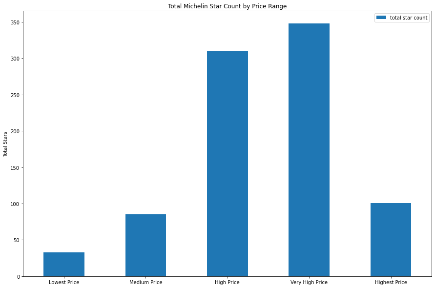

```python
prices = [0, 0, 0, 0, 0]

#as we are using the prices themselves as row indices, we do not need a dictionary and can do everything in linear time with just an array
#we just need to subtract one because arrays are indexed starting at zero
for index, row in all_stars.iterrows():
    prices[all_stars.at[index, 'price'] - 1] += all_stars.at[index, 'num_stars']

index = ["Lowest Price", "Medium Price", "High Price", "Very High Price", "Highest Price"]
df = pandas.DataFrame({'total star count': prices}, index=index)
ax = df.plot.bar(rot=0, figsize=(15, 10), title='Total Michelin Star Count by Price Range')
ax.set_ylabel("Total Stars")
```

The results here were also very interesting. My inital hypothesis was that there would be a strictly positive relationship between price and the amount of Michelin star's awarded to a restaurant. This is clearly not the case, after the Very High Price range, we see a steep drop in the amount of stars awarded. Now one reason for this could be because there are just fewer restaurants at the highest price level. But it is also possible that Michelin intends to award more stars to restaurants a large amount of people can actually go to, as again, we can see a relationship between stars awarded and car ownership.

To examine this further, I created three more plots, with the number of one star, two star, and three star restaurants by price range. Again the results were interesting. We can see the majority of ratings awarded are just one star and those are mostly high priced. The two and three star restaurants are mostly very high priced and surprisingly there are actually more one and two star restaurants at the highest price range.

So my hypothesis was right in the sense that stars awarded does seem to have a positive relationship with the price of a restuarant. However, this realtionship is only positive up to a point and after a certain price (depending on the number of stars to be awarded) there is a steep drop off in the amount of stars awarded. This information will be very helpful in predicting star ratings of restaurants.

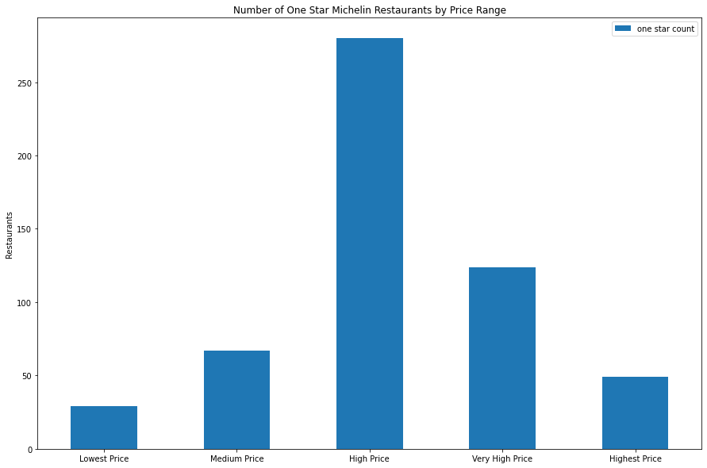

```python
prices1 = [0, 0, 0, 0, 0]

#as we are using the prices themselves as row indices, we do not need a dictionary and can do everything in linear time with just an array
#we just need to subtract one because arrays are indexed starting at zero
for index, row in one_star.iterrows():
    prices1[one_star.at[index, 'price'] - 1] += one_star.at[index, 'num_stars']

index = ["Lowest Price", "Medium Price", "High Price", "Very High Price", "Highest Price"]
df = pandas.DataFrame({'one star count': prices1}, index=index)
ax = df.plot.bar(rot=0, figsize=(15, 10), title='Number of One Star Michelin Restaurants by Price Range')
ax.set_ylabel("Restaurants")
```

[figure not shown]

```python
prices2 = [0, 0, 0, 0, 0]

#as we are using the prices themselves as row indices, we do not need a dictionary and can do everything in linear time with just an array
#we just need to subtract one because arrays are indexed starting at zero
for index, row in two_star.iterrows():
    prices2[two_star.at[index, 'price'] - 1] += two_star.at[index, 'num_stars']

index = ["Lowest Price", "Medium Price", "High Price", "Very High Price", "Highest Price"]
df = pandas.DataFrame({'two star count': prices2}, index=index)
ax = df.plot.bar(rot=0, figsize=(15, 10), title='Number of Two Star Michelin Restaurants by Price Range')
ax.set_ylabel("Restaurants")
```

[figure not shown]

```python
prices3 = [0, 0, 0, 0, 0]

#as we are using the prices themselves as row indices, we do not need a dictionary and can do everything in linear time with just an array
#we just need to subtract one because arrays are indexed starting at zero
for index, row in three_star.iterrows():
    prices3[three_star.at[index, 'price'] - 1] += three_star.at[index, 'num_stars']

index = ["Lowest Price", "Medium Price", "High Price", "Very High Price", "Highest Price"]
df = pandas.DataFrame({'three star count': prices3}, index=index)
ax = df.plot.bar(rot=0, figsize=(15, 10), title='Number of Three Star Michelin Restaurants by Price Range')
ax.set_ylabel("Restaurants")
```

### Machine Learning:

We have examined several aspects of the dataset, like continent, price, and cuisine and we can see relationships between these variables and the number of stars awarded. Now we can attempt to predict the number of stars a restaurant has using a machine learning model. Our dependent variable each time will obviously be num_stars. Our indepdent variables will always include price and cuisine.

First, we can drop all the columns we won't be using in the prediction model, name, latitude, longitude, city, and region.

```python
all_stars = all_stars.drop(columns=['name', 'latitude', 'longitude', 'city', 'region'])
all_stars2 = all_stars.copy()
all_stars3 = all_stars.copy()
all_stars.head()
```

|  | cuisine | price | num_stars | continent |
| --- | --- | --- | --- | --- |
| 0 | Creative | 5 | 1 | Europe |
| 1 | Classic cuisine | 5 | 1 | Europe |
| 2 | Creative | 5 | 1 | Europe |
| 3 | Market cuisine | 5 | 1 | Europe |
| 4 | Modern cuisine | 4 | 1 | Europe |

As cuisine and continent are both categorical varaibles, we need to use one-hot encoding to convert them to numerical. For this, we can use get_dummies, which is a simple pandas function that allows us to create a new column with a binary variable for each possible categorical variable.

https://pandas.pydata.org/docs/reference/api/pandas.get_dummies.html

```python
all_stars = pd.get_dummies(all_stars, columns = ['continent'])
all_stars = pd.get_dummies(all_stars, columns = ['cuisine'])

all_stars.head()
```

|  | price | num_stars | continent_Asia | continent_Europe | continent_North America | continent_South America | cuisine_American | cuisine_Asian | cuisine_Asian contemporary | cuisine_Asian influences | ... | cuisine_Taiwanese | cuisine_Taizhou | cuisine_Temple cuisine | cuisine_Teppanyaki | cuisine_Thai | cuisine_Thai Contemporary | cuisine_Traditional British | cuisine_Vegetarian | cuisine_creative | cuisine_modern |
| --- | --- | --- | --- | --- | --- | --- | --- | --- | --- | --- | --- | --- | --- | --- | --- | --- | --- | --- | --- | --- | --- |
| 0 | 5 | 1 | 0 | 1 | 0 | 0 | 0 | 0 | 0 | 0 | ... | 0 | 0 | 0 | 0 | 0 | 0 | 0 | 0 | 0 | 0 |
| 1 | 5 | 1 | 0 | 1 | 0 | 0 | 0 | 0 | 0 | 0 | ... | 0 | 0 | 0 | 0 | 0 | 0 | 0 | 0 | 0 | 0 |
| 2 | 5 | 1 | 0 | 1 | 0 | 0 | 0 | 0 | 0 | 0 | ... | 0 | 0 | 0 | 0 | 0 | 0 | 0 | 0 | 0 | 0 |
| 3 | 5 | 1 | 0 | 1 | 0 | 0 | 0 | 0 | 0 | 0 | ... | 0 | 0 | 0 | 0 | 0 | 0 | 0 | 0 | 0 | 0 |
| 4 | 4 | 1 | 0 | 1 | 0 | 0 | 0 | 0 | 0 | 0 | ... | 0 | 0 | 0 | 0 | 0 | 0 | 0 | 0 | 0 | 0 |

5 rows × 76 columns

And now this dataset can be used in a logistic regression model https://scikit-learn.org/stable/modules/generated/sklearn.linear_model.LogisticRegression.html

```python
import re
from sklearn.preprocessing import StandardScaler
from sklearn.model_selection import train_test_split

from sklearn.linear_model import LogisticRegression
from warnings import simplefilter
from sklearn.exceptions import ConvergenceWarning
simplefilter("ignore", category=ConvergenceWarning)

#splitting the dataset into the dependent and independent variables
y = all_stars['num_stars'].copy()
X = all_stars.drop('num_stars', axis=1)

#creating training and testing sets
X = StandardScaler().fit_transform(X)
X_train, X_test, y_train, y_test = train_test_split(X, y, train_size=0.7, random_state=40)

#fitting the model, using the default Logistic Regression hyperparameters
model = LogisticRegression()
model.fit(X_train, y_train)
models.append(model)
print("Accuracy : ", model.score(X_test, y_test))
```

```
Accuracy :  0.7799043062200957
```

A prediction accuracy of 77.9% isn't bad but we can probably do better via hyperparameter tuning. The default parameter C for LogisticRegression is 1.0 according to the documentation. We can try a variety of other C values using a simple for loop

```python
hyper = [0.0001, 0.001, 0.01, 0.1, 1.0, 10.0, 100.0]

for i in range(len(hyper)):
    model = LogisticRegression(C=hyper[i])
    model.fit(X_train, y_train)
    models.append(model)
    print("Accuracy where C =", hyper[i], ":",model.score(X_test, y_test))
```

```
Accuracy where C = 0.0001 : 0.8229665071770335
Accuracy where C = 0.001 : 0.8229665071770335
Accuracy where C = 0.01 : 0.8229665071770335
Accuracy where C = 0.1 : 0.8038277511961722
Accuracy where C = 1.0 : 0.7799043062200957
Accuracy where C = 10.0 : 0.7799043062200957
Accuracy where C = 100.0 : 0.7751196172248804
```

So with a hyperparameter C of 0.0001, 0.001, or 0.01 we can actually get our accuracy up to 82%, which is better. And it demonstrates the fact that the Michelin rating system is biased enough that we can reliably predict a restaurants star rating just by the continent it is in, the price range, and the cuisine it serves.

### Conclusion:

As the testing has demonstrated, several of my hypotheses were shown to be true. Michelin does seem to favor restaurants in Europe and America and a strong positive relationship exists between awarded stars and car ownership. They appear to award a dispropotionate amount of stars to restaurants serving French and Japanese cuisine, like my research suggested they would, though they were not quite as popular with Michelin as modern/contemporary cuisine. And finally, there was in fact a strong positive correlation between the price of a restuarant and the amount of stars it was awarded, with all restaurants except for the most expensive, which could be explained by a variety of reasons. Because of these relationships, I was able to train a model to predict the amount of stars awarded to a restaurant with over 80% accuracy, whereas a truly unbiased awards system would be unable to be predicted.

It is likely impossible to make a ranking system of restaurants that is without any bias at all. However, that does not mean Michelin should not make more efforts to reduce their biases and award restaurants on their merits, rather than in a way that serves to profit their own company and reinforce stereotypes and social prejudices. Michelin is not a charity, but in recent years many large companies have realized the social responsibility they owe to the general public. Consumers have taken notice as well and have rightfuly led boycotts against companies they feel are not doing enough to promote equality and representation among marginalized communites. Michelin Stars do not just stroke the ego of restaurant owners, they have very real impacts on tourism and economics of the regions where they are awarded. There are certainly many restaurants worthy of stars that Michelin should make more efforts to seek out and find, which would in turn increase the tourism and revenue of not just the restaurant awarded to, but to the surrounding community.

I think the first thing Michelin should do is begin awarding Michelin stars to restaurants in Africa and Oceania! I had a lot of fun working on this project and I hope you enjoyed reading it.